# Developing Data Products Group 010 Course Project

Andrey Vykhodtsev

25 Jan 2015

# Analysis of average prices by Borough, London, UK

## Introduction

The purpose and criteria for this course project is to demonstrate development of data products using [Shiny project](http://shiny.rstudio.com/) and [rCharts](http://rcharts.io/) Also, the secondary goal is to demonstrate the possibilities for interactive visualisations on the data examples that are participating in [IBM Data For Social Good Challenge](http://ibmhadoop.challengepost.com/details/data)

## Analysis navigation menu

On the left there is a sidebar that allows you to choose areas of London and years. There are 47 different areas and 18 years of data, years range from 1996 to 2013. On the right, there is main panel, that allows you to choose the data representation from one of those :

- Boxplot
- Barplot
- Scatterplot
- Table

Each of those data representations react to what you choose in the sidebar. If you don’t select anything, the application will show you the full dataset.

### Meaning of each chart

Boxplot shows you the distribution of prices per year.

Scatterplot shows you values by each year. You can check the tooltip for each value to see which borough it corresponds to.

Barplot shows the relative prices by borough for each year. You can choose stacked or grouped representation.

### Selecting values and displaying charts

Here is the screenshot of empty select input for area:

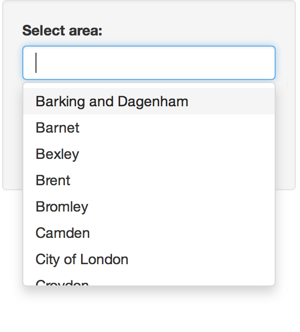

If you choose particular areas and years, all plots and tables change appearance:

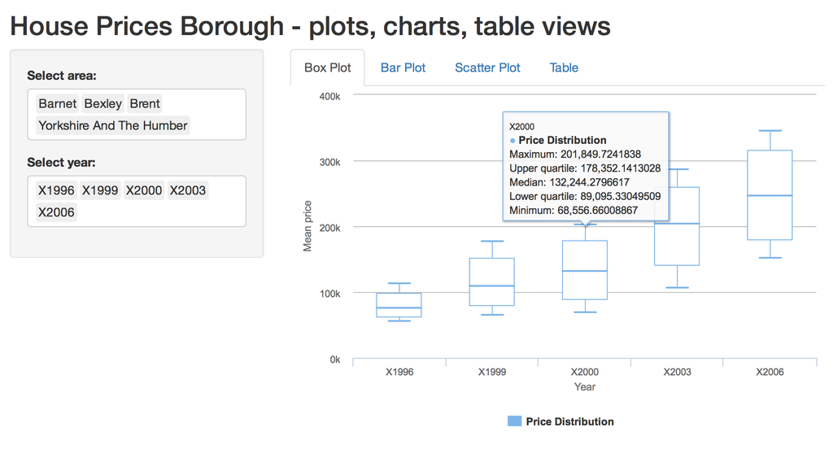

You can see that plots contain useful tooltips to show you which value each element is describing.

## Motion chart tab

Motion chart tab is made using googleVis MotionChart, and allows you to do different kinds of exlporarion all at once:

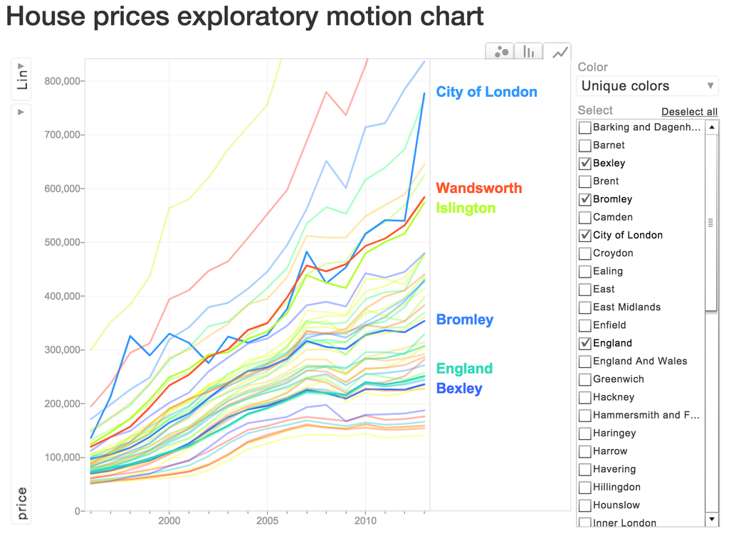

## Data source

The data for this project is taken from [this source](http://data.london.gov.uk/dataset/average-house-prices-borough)

This data represents the yearly change in prices for different regions of London, UK.

For the purposes of this analysis we are using summary data stored in [this xls file](https://londondatastore-upload.s3.amazonaws.com/average-house-prices-borough.xls).

## Preprocessing and analysing data

Data we are using is taken from the sheet 3 “Mean prices anually”.

The data is loaded using “xlsx” package. Then it is preprocessed to eliminate NA values. After that we use *tidyr* package to gather different year columns into the key/value pairs -> year/price.